# M2.983_2022_1_PAC1-Sol

[figure not shown]

M2.983 · Aprenentatge per reforç

2022-1 · Màster universitari en Ciència de dades (*Data science*)

Estudis d'Informàtica, Multimèdia i Telecomunicacions

**Nom i cognoms:** Jordi Puig Ovejero  
Nota: aquesta pràctica s'ha realitzat amb l'ajuda [dels exemples de l'assignatura](https://github.com/jcasasr/Aprendizaje-por-refuerzo)

# PAC 1 - Solucions tabulars

En aquesta pràctica implementarem els diferents mètodes d'aprenentatge per reforç vistos a les parts I i II del curs. Concretament, ens centrarem en la definició d'un entorn i implementarem els diferents mètodes per cercar una solució òptima del problema.

Consideracions generals:

- Aquesta PAC s'ha de fer de manera **estrictament individual**. Qualsevol indici de còpia serà penalitzat amb un suspens (D) per a totes les parts implicades i la possible avaluació negativa de l'assignatura de forma íntegra.
- Cal que l'estudiant indiqui **totes les fonts** que ha fet servir per a la realització de la PAC. Si no és així, es considerarà que l'estudiant ha comès plagi, i és penalitzat amb un suspens (D) i la possible avaluació negativa de l'assignatura de forma íntegra.

Format de l'entrega:

- Alguns exercicis poden suposar diversos minuts d'execució, per la qual cosa el lliurament s'ha de fer a format notebook ia format HTML, on es vegi el codi, els resultats i comentaris de cada exercici. Es pot exportar el notebook a HTML des del menú File $\to$ Download as $\to$ HTML.
- Hi ha un tipus de cel·la especial per allotjar text. Aquest tipus de cel·la us serà molt útil per respondre les diferents preguntes teòriques plantejades al llarg de lactivitat. Per canviar el tipus de cel·la a aquest tipus, accediu al menú: Cell $\to$ Cell Type $\to$ Markdown.

## 0. El entorno **BlackJack**

L'entorn **BlackJack** simula una partida de blackjack, que es juga amb una baralla francesa de 52 cartes (baralla de pòquer), constituïda per 4 pals (trèvol ♣, cors ♥, piques ♠, i diamants ♦) i 13 cartes per pal (As , els números del 2 al 10, J, Q i K).

L'objectiu d'aquest joc és obtenir cartes el valor numèric de les quals sumin el nombre més gran possible sense excedir de 21.

Totes aquelles cartes amb un valor numèric compten com a dit valor numèric, les figures (J, Q i K) compten com un 10, i l'as pot comptar com un 1 (en aquest cas s'anomena as no usable) o com un 11 ( en aquest cas es denomina as usable).

A la figura següent es pot observar el valor numèric de tots els tipus de cartes:

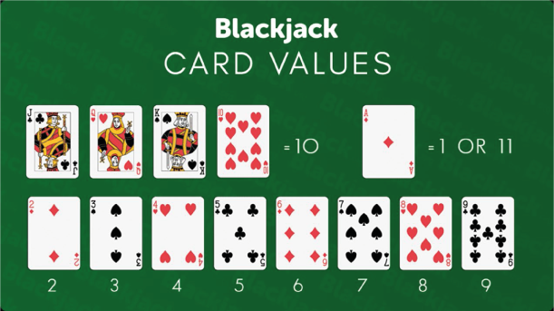

**Figura 1. El joc del Blackjack.** (Font: Sutton & Barto, 1998)

Les normes del joc estan explicades al mòdul 5 de l'assignatura.

Jugar al blackjack pot ser formulat de forma natural com un MDP finit i episòdic

• Cada partida de blackjack és un episodi.  
• Les recompenses són: +1 per guanyar, -1 per perdre i 0 per empatar.  
• El retorn es calcula sense descompte (γ = 1).  
• El conjunt d'accions del jugador és demanar carta (hit) o plantar-se (stick). És a dir: A = {hit,stick}.  
• Els estats depenen de les cartes del jugador i de la carta que mostra el crupier.  
• El jugador pren decisions basant-se en tres variables:  
– Si li ha sortit un as que pugui comptar com a 11 sense passar-se (usable ace a anglès).  
– La suma actual de les cartes (de 12 a 21).  
– El valor de la carta de panxa enlaire del crupier.  
• Això fa un total de 200 estats diferents.

L'entorn que utilitzarem inicialment implementa totes les característiques comentades anteriorment i la política següent per al crupier:

• Es planta si la suma és 17 o més gran, demana carta en un altre cas.

El codi per implementar aquest entorn està disponible al fitxer adjunt `blackjack_env.py`

Començarem carregant l'entorn i veure quines característiques té, executant un episodi de prova.

### 0.1. Càrrega de dades

El codi següent carrega els paquets necessaris per executar l'exemple, crea l'entorn mitjançant la instanciació d'un objecte de la classe `BlackjackEnv` (importada del fitxer adjunt `blackjack_env.py`) i imprimeix per pantalla la dimensió de l'espai d'accions (0 =plantar-se, 1=demanar carta), de l'espai d'observacions (una tupla de 3 elements: la suma actual del jugador, la carta que mostra el crupier amb valors 1-10, on 1 és un as, i si el jugador té o no un as utilitzable) i el rang de la variable de recompensa (el valor del qual és -1, 0 o 1 depenent de si el jugador perd, empata o guanya la partida i que per tant va de menys infinit a més infinit).

```python
#Executar aquesta cel·la només si executem aquest notebook a Google Colab des de Drive
#from google.colab import drive
#drive.mount('/content/drive')
#MODIFICAR D'ACORD A LA RUTA DE LES TEVES CARPETES
#%cd /content/drive/My Drive/Reinforcement Learning/PAC1_T2022/
```

```python
import numpy as np
import blackjack_env as bj1

env=bj1.BlackjackEnv()
print("Action space is {} ".format(env.action_space))
print("Observation space is {} ".format(env.observation_space))
print("Reward range is {} ".format(env.reward_range))
```

```
Action space is Discrete(2)
Observation space is Tuple(Discrete(32), Discrete(11), Discrete(2))
Reward range is (-inf, inf)
```

### 0.2. Execució d'un episodi

A continuació, realitzarem l'execució d'un episodi de l'entorn `BlackjackEnv` utilitzant un agent que selecciona les accions de forma aleatòria.

```python
# Inicialitzem l'entorn
obs = env.reset()
t, total_reward, done = 0, 0, False

print("Obs inicial: Player = {}, Dealer = {}, Usable Ace = {} ".format(obs[0],obs[1],obs[2]))

switch_action = {
        0: "Stick",
        1: "Hit",
    }

while not done:

    # Elegir una acción aleatoria (ésta es la implementación del agente)
    action = env.action_space.sample()

    # Ejecutar la acción y esperar la respuesta del entorno
    new_obs, reward, done, info = env.step(action)

    # Imprimir time-step
    print("Action: {} -> Obs: Player = {}, Dealer = {}, Usable Ace = {} and reward: {}".format(switch_action[action], new_obs[0],new_obs[1],new_obs[2], reward))

    # Actualizar variables
    obs = new_obs
    total_reward += reward
    t += 1

print("Episodio finalizado después de {} pasos y la recompensa fue {} ".format(t, total_reward))
env.close()
```

```
Obs inicial: Player = 16, Dealer = 7, Usable Ace = False
Action: Stick -> Obs: Player = 16, Dealer = 7, Usable Ace = False and reward: -1
Episodio finalizado después de 1 pasos y la recompensa fue -1
```

## 1. Anàlisi i modificació de l'entorn (2 punts)

**Exercici 1.1** (0,5 punts)

Analitzar el codi del fitxer de l'entorn (fitxer adjunt `blacjack_env.py`) i documentar totes les funcions (emplenar els comentaris on posa `""" Descripción """`).

Desar el fitxer amb el mateix nom `blackjack_env.py`. Aquest fitxer s'ha de lliurar juntament amb els fitxers d'aquest notebook (.ipynb y .html).

**Exercici 1.2** (0,5 punts)

Al joc de Blackjack que es juga als casinos hi ha una petita diferència quant a les recompenses: si un jugador guanya una partida amb un natural (les 2 primeres cartes sumen 21) rep una recompensa d'1,5 punts.

Una explicació es pot trobar al següent [enllaç](http://www.bicyclecards.com/how-to-play/blackjack/).

Modificar el codi de BlackjackEnv (fitxer adjunt `blacjack_env.py`) perquè atorgui una puntuació d'1,5 en cas que el jugador tingui un natural de mà i el crupier no.

Desar l'entorn modificat al fitxer `blackjack_env_v2.py`, a la mateixa carpeta que l'original. Aquest fitxer s'ha de lliurar juntament amb els fitxers d'aquest notebook (.ipynb i .html) i l'entorn original documentat.

```python
import gym
import numpy as np
import blackjack_env_v2 as bj2

env=bj2.BlackjackEnv()
print("Action space is {} ".format(env.action_space))
print("Observation space is {} ".format(env.observation_space))
print("Reward range is {} ".format(env.reward_range))
```

```
Action space is Discrete(2)
Observation space is Tuple(Discrete(32), Discrete(11), Discrete(2))
Reward range is (-inf, inf)
```

**Exercici 1.3** (0,75 punts)

A continuació, implementar un agent que dugui a terme la política determinista següent: l'agent es plantarà si obté una puntuació de 20 o 21.

Jugar partides fins que l'agent guanyi la partida mitjançant un natural per comprovar que la implementació és correcta. Mostra el resultat d'aquesta partida.

```python
# Inicialitzem l'entorn
obs = env.reset()
t, total_reward, done = 0, 0, False

print("Obs inicial: Player = {}, Dealer = {}, Usable Ace = {} ".format(obs[0],obs[1],obs[2]))

switch_action = {
        0: "Stick",
        1: "Hit",
    }
```

```
Obs inicial: Player = 12, Dealer = 10, Usable Ace = False
```

```python
######################## SOLUCIÓ ###########################
is_natural = False
games = 0
while not is_natural:
    while not done:
        # Si la mà inicial és 20 o 21 ens plantem sino agafem una acció aleatoria
        if obs[0] >= 20:
            action = 0
        else:
            action = env.action_space.sample()

        # Ejecutar la acción y esperar la respuesta del entorno
        new_obs, reward, done, info = env.step(action)

        # Imprimir time-step
        print("Action: {} -> Obs: Player = {}, Dealer = {}, Usable Ace = {} and reward: {}".format(switch_action[action], new_obs[0],new_obs[1],new_obs[2], reward))

        # Actualizar variables
        obs = new_obs
        total_reward += reward
        t += 1
    if reward == 1.5:
        is_natural = True
    else:
        obs = env.reset()
        done = False
    games += 1
print("Natural obtingut després de {} partides amb una recompensa total de {} ".format(games, total_reward))
env.close()
```

```
Action: Hit -> Obs: Player = 19, Dealer = 10, Usable Ace = False and reward: 0
Action: Hit -> Obs: Player = 25, Dealer = 10, Usable Ace = False and reward: -1
Action: Stick -> Obs: Player = 18, Dealer = 6, Usable Ace = False and reward: -1
Action: Stick -> Obs: Player = 16, Dealer = 10, Usable Ace = False and reward: -1
Action: Stick -> Obs: Player = 14, Dealer = 10, Usable Ace = False and reward: -1
Action: Hit -> Obs: Player = 23, Dealer = 4, Usable Ace = False and reward: -1
Action: Stick -> Obs: Player = 13, Dealer = 2, Usable Ace = False and reward: -1
Action: Hit -> Obs: Player = 22, Dealer = 6, Usable Ace = False and reward: -1
Action: Stick -> Obs: Player = 18, Dealer = 4, Usable Ace = False and reward: 0
Action: Hit -> Obs: Player = 17, Dealer = 1, Usable Ace = False and reward: 0
Action: Hit -> Obs: Player = 27, Dealer = 1, Usable Ace = False and reward: -1
Action: Stick -> Obs: Player = 12, Dealer = 3, Usable Ace = False and reward: -1
Action: Stick -> Obs: Player = 16, Dealer = 10, Usable Ace = False and reward: -1
Action: Stick -> Obs: Player = 15, Dealer = 10, Usable Ace = False and reward: -1
Action: Stick -> Obs: Player = 20, Dealer = 10, Usable Ace = False and reward: 0
Action: Hit -> Obs: Player = 17, Dealer = 10, Usable Ace = False and reward: 0
Action: Hit -> Obs: Player = 26, Dealer = 10, Usable Ace = False and reward: -1
Action: Hit -> Obs: Player = 27, Dealer = 2, Usable Ace = False and reward: -1
Action: Stick -> Obs: Player = 20, Dealer = 7, Usable Ace = False and reward: 1
Action: Hit -> Obs: Player = 12, Dealer = 10, Usable Ace = False and reward: 0
Action: Hit -> Obs: Player = 17, Dealer = 10, Usable Ace = False and reward: 0
Action: Hit -> Obs: Player = 23, Dealer = 10, Usable Ace = False and reward: -1
Action: Hit -> Obs: Player = 19, Dealer = 1, Usable Ace = False and reward: 0
Action: Hit -> Obs: Player = 26, Dealer = 1, Usable Ace = False and reward: -1
Action: Hit -> Obs: Player = 19, Dealer = 4, Usable Ace = False and reward: 0
Action: Stick -> Obs: Player = 19, Dealer = 4, Usable Ace = False and reward: 1
Action: Hit -> Obs: Player = 21, Dealer = 8, Usable Ace = False and reward: 0
Action: Stick -> Obs: Player = 21, Dealer = 8, Usable Ace = False and reward: 1
Action: Hit -> Obs: Player = 21, Dealer = 10, Usable Ace = False and reward: 0
Action: Stick -> Obs: Player = 21, Dealer = 10, Usable Ace = False and reward: 1
Action: Hit -> Obs: Player = 24, Dealer = 6, Usable Ace = False and reward: -1
Action: Hit -> Obs: Player = 13, Dealer = 10, Usable Ace = False and reward: 0
Action: Stick -> Obs: Player = 13, Dealer = 10, Usable Ace = False and reward: 1
Action: Stick -> Obs: Player = 14, Dealer = 6, Usable Ace = False and reward: 1
Action: Hit -> Obs: Player = 15, Dealer = 9, Usable Ace = False and reward: 0
Action: Hit -> Obs: Player = 20, Dealer = 9, Usable Ace = False and reward: 0
Action: Stick -> Obs: Player = 20, Dealer = 9, Usable Ace = False and reward: -1
Action: Hit -> Obs: Player = 23, Dealer = 10, Usable Ace = False and reward: -1
Action: Stick -> Obs: Player = 18, Dealer = 3, Usable Ace = False and reward: 1
Action: Stick -> Obs: Player = 19, Dealer = 7, Usable Ace = False and reward: -1
Action: Hit -> Obs: Player = 23, Dealer = 10, Usable Ace = False and reward: -1
Action: Stick -> Obs: Player = 21, Dealer = 10, Usable Ace = True and reward: 1.5
Natural obtingut després de 30 partides amb una recompensa total de -11.5
```

**Exercici 1.4** (0,25 punts)

Utilitzant l'agent i l'entorn de l'apartat anterior, simuleu 100.000 partides i calculeu el retorn de l'agent (recompensa total acumulada).

Calculeu el % de victòries, naturals, derrotes i empats. Comentar-ne els resultats.

```python
# Inicialitzem l'entorn
obs = env.reset()
total_reward, done = 0, False

print("Obs inicial: Player = {}, Dealer = {}, Usable Ace = {} ".format(obs[0],obs[1],obs[2]))

switch_action = {
        0: "Stick",
        1: "Hit",
    }
```

```
Obs inicial: Player = 21, Dealer = 9, Usable Ace = True
```

```python
######################## SOLUCIÓ ###########################
# Definim la política amb una estructura de dades de clau - valor. La clau és el valor del player i el valor és l'acció.
sample_policy = {
    20: 0,
    21: 0
}


# Aquest mètode executa una partida amb la política definida a sample_policy.
# Si el valor es 20, sample_policy retorna 0 que indica que ens plantem. En cas contrari, executa de forma aleatoria.
def play_game(policy):
    obs = env.reset()
    total_reward, done = 0, False

    switch_action = {
        0: "Stick",
        1: "Hit",
    }

    while not done:
        # Si la mà és 20 o 21 ens plantem sino agafem una acció aleatoria. Apliquem la policy que passem per paràmetre.
        action = policy.get(obs[0])
        if action is None:
            action = env.action_space.sample()

        # Executem l'acció y esperem la resposta de l'entorn
        new_obs, reward, done, info = env.step(action)

        # Actualizar variables
        obs = new_obs
        total_reward += reward

    env.close()

    return reward


# Calcula el percentatge entre num_a i num_b
def percent_of(num_a, num_b):
    return (num_a / num_b) * 100


# Executa tantes vegades com el paràmetre d'entrada games, amb l'environtment env i la política sample_policy.
# Depenen del resultat incrementem un comptador o un altre.
# Finalment printem els percentatges.
def play_games_natural(env, sample_policy, games):
    total_reward = 0
    current_game = 0
    total_win = 0
    total_lose = 0
    total_natural = 0
    total_draw = 0

    while current_game < games:
        reward = play_game(sample_policy)
        if (reward == 0):
            total_draw += 1
        elif (reward == -1):
            total_lose += 1
        elif (reward == 1):
            total_win += 1
        elif (reward == 1.5):
            total_natural += 1
        total_reward += reward
        current_game = current_game + 1

    return total_reward, total_win, total_lose, total_natural, total_draw
```

**Comentaris:**

```python
games = 100000

total_reward, total_win, total_lose, total_natural, total_draw = play_games_natural(env, sample_policy, games)

print("{} jocs executats amb una recompensa total de {} ".format(games, total_reward))
print("El nombre de victories totals és de {} amb un percentatge del {}%".format(total_natural+total_win, percent_of(total_natural+total_win, games)))
print("El nombre de victories naturals és de {} amb un percentatge del {}%".format(total_natural, percent_of(total_natural, games)))
print("El nombre de victories no naturals és de {} amb un percentatge del {}%".format(total_win, percent_of(total_win, games)))
print("El nombre de derrotes és de {} amb un percentatge del {}%".format(total_lose, percent_of(total_lose, games)))
print("El nombre d'empats és de {} amb un percentatge del {}%".format(total_draw, percent_of(total_draw, games)))
```

```
100000 jocs executats amb una recompensa total de -14806.0
El nombre de victories totals és de 37818 amb un percentatge del 37.818000000000005%
El nombre de victories naturals és de 6586 amb un percentatge del 6.586%
El nombre de victories no naturals és de 31232 amb un percentatge del 31.232%
El nombre de derrotes és de 55917 amb un percentatge del 55.916999999999994%
El nombre d'empats és de 6265 amb un percentatge del 6.265%
```

Després dels 100000 jocs executats veiem que les victories totals del player estan per sobre del 37% mentre que les del dealer arriban quasi al 56%. Està clar que aquesta política, encara que és millor que no pas totalment aleatoria, no és la óptima i segurament si fem que es planti amb valors per sota de 20 com fa el dealer millorarem aquest percentatge.

Observació: hem comentat els logs tant del agent com del environtment per no embrutar la sortida de la execució.

## 2. Política òptima (2 punts)

Atès que l'entorn utilitzat a les simulacions del mòdul 5 s'ha fet sense l'assiganció extra d'1,5 per al cas d'un natural, i amb l'objectiu de reproduir els mateixos resultats, farem servir l'entorn original proporcionat amb l'enunciat.

**NOTA IMPORTANT:** Utilitzar el següent entorn a la resta d'apartats de la PAC

```python
env = bj1.BlackjackEnv()
```

Al mòdul 5 sobre els mètodes de Montecarlo s'analitza l'exemple del Blackjack i es resol l'escenari arribant a la política òptima següent:

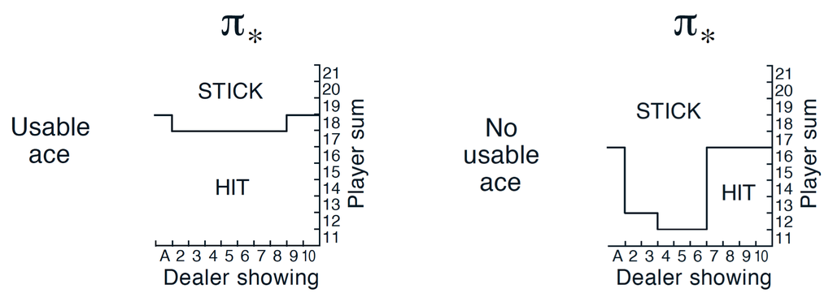

**Figura 2. Polítiques òptimes.** Font: Sutton & Barto, 2018

A continuació us proporcionem alguns escenaris d'exemple extrets de la figura:

| **Usable Ace** | **Dealer** | **Player_Sum** | **Action** |
| --- | --- | --- | --- |
| Yes | 5 | 17 | HIT |
| Yes | 2 | 19 | STICK |
| Yes | 9 | 18 | HIT |
| Yes | 9 | 20 | STICK |
| No | 2 | 5 | HIT |
| No | 2 | 14 | STICK |
| No | 4 | 11 | HIT |
| No | 6 | 12 | STICK |
| No | 7 | 5 | HIT |
| No | 8 | 17 | STICK |

**Exercici 2.1** (1 punt)

Implementar un agent que executi la política òptima definida una mica més amunt. En el cas de la suma de les cartes del jugador, només cal implementar a partir de 12 (inclòs), ja que l'entorn fa que sempre demani una altra carta si està per sota d'aquest valor.

```python
# Inicialitzem l'entorn
env = bj1.BlackjackEnv()
obs = env.reset()
total_reward, done = 0, False

print("Obs inicial: Player = {}, Dealer = {}, Usable Ace = {} ".format(obs[0],obs[1],obs[2]))

switch_action = {
        0: "Stick",
        1: "Hit",
    }
```

```
Obs inicial: Player = 19, Dealer = 10, Usable Ace = False
```

```python
######################## SOLUCIÓ ###########################

# La política óptima és construeix amb un map amb la clau Usable ace + Dealer showing.
# El valor és el valor màxim de hit. A partir d'aquell valor farem Stick.
optimal_policy = {}
optimal_policy[(True, 1)]=18
optimal_policy[(True, 2)]=17
optimal_policy[(True, 3)]=17
optimal_policy[(True, 4)]=17
optimal_policy[(True, 5)]=17
optimal_policy[(True, 6)]=17
optimal_policy[(True, 7)]=17
optimal_policy[(True, 8)]=17
optimal_policy[(True, 9)]=18
optimal_policy[(True, 10)]=18
optimal_policy[(False, 1)]=16
optimal_policy[(False, 2)]=12
optimal_policy[(False, 3)]=12
optimal_policy[(False, 4)]=11
optimal_policy[(False, 5)]=11
optimal_policy[(False, 6)]=11
optimal_policy[(False, 7)]=16
optimal_policy[(False, 8)]=16
optimal_policy[(False, 9)]=16
optimal_policy[(False, 10)]=16

while not done:

     # obtenim el valor màxim que pot tenir el player a partir de la política
     max_player = optimal_policy[obs[2], obs[1]]
     if obs[0] <= max_player:
         action = 1
     else:
         action = 0
     # Executem l'acció y esperem la resposta de l'entorn
     new_obs, reward, done, info = env.step(action)
     # Imprimim el valor de la observació de l'estat actual
     print("Action: {} -> Obs: Player = {}, Dealer = {}, Usable Ace = {} and reward: {}".format(switch_action[action], new_obs[0],new_obs[1],new_obs[2], reward))

     # Actualizar variables
     obs = new_obs
     total_reward += reward

print("Episodi finalitzat i la recompensa és de {} ".format(total_reward))
env.close()
```

```
Action: Stick -> Obs: Player = 19, Dealer = 10, Usable Ace = False and reward: -1
Episodi finalitzat i la recompensa és de -1
```

Hem implementat la política definida amb el map esmentat. Segons el valor retornat a partir de la mà inicial, podem definir el màxim valor on arrriba el player.

**Exercici 2.2** (0,5 punts)

Comprovació de resultats. Implementar una funció que imprimeixi la política per pantalla per comprovar que l'agent implementat executa correctament la política òptima.

**NOTA:** Només cal verificar-ho per als estats de la Figura 2 (Player sum = 12-21, Dealer = 1-10, Usable/No usable ace).

```python
######################## SOLUCIÓ ###########################

# Aquesta funció implementa la política esmentada.
# Amb el map amb la key[Usable Ace,Valor del dealer] i el valor retornat és el màxim valor que el player farà hit.
# El retorn és l'acció 1 per Hit i 0 per Stick.
def optimal_policy(player, dealer, usable_ace):
    optimal_policy = {}
    optimal_policy[(True, 1)] = 18
    optimal_policy[(True, 2)] = 17
    optimal_policy[(True, 3)] = 17
    optimal_policy[(True, 4)] = 17
    optimal_policy[(True, 5)] = 17
    optimal_policy[(True, 6)] = 17
    optimal_policy[(True, 7)] = 17
    optimal_policy[(True, 8)] = 17
    optimal_policy[(True, 9)] = 18
    optimal_policy[(True, 10)] = 18
    optimal_policy[(False, 1)] = 16
    optimal_policy[(False, 2)] = 12
    optimal_policy[(False, 3)] = 12
    optimal_policy[(False, 4)] = 11
    optimal_policy[(False, 5)] = 11
    optimal_policy[(False, 6)] = 11
    optimal_policy[(False, 7)] = 16
    optimal_policy[(False, 8)] = 16
    optimal_policy[(False, 9)] = 16
    optimal_policy[(False, 10)] = 16

    max_player = optimal_policy[usable_ace, dealer]
    if player <= max_player:
        action = 1
    else:
        action = 0

    return action


# Aquesta funció printa per cada una de les combinacions possibles el valor de la política.
def print_policy_opt(optimal_policy):
    for b_usable_ace in (0, 1):
        for i_player in range(12, 22):
            for i_dealer in range(1, 11):
                action = optimal_policy(i_player, i_dealer, b_usable_ace == 0)
                print("Usable Ace: {}, Dealer: {}, Player: {}, Action: {}".format(
                    b_usable_ace == 0, i_dealer, i_player, switch_action[action]))
```

```python
print_policy_opt(optimal_policy)
```

```
Usable Ace: True, Dealer: 1, Player: 12, Action: Hit
Usable Ace: True, Dealer: 2, Player: 12, Action: Hit
Usable Ace: True, Dealer: 3, Player: 12, Action: Hit
Usable Ace: True, Dealer: 4, Player: 12, Action: Hit
Usable Ace: True, Dealer: 5, Player: 12, Action: Hit
Usable Ace: True, Dealer: 6, Player: 12, Action: Hit
Usable Ace: True, Dealer: 7, Player: 12, Action: Hit
Usable Ace: True, Dealer: 8, Player: 12, Action: Hit
Usable Ace: True, Dealer: 9, Player: 12, Action: Hit
Usable Ace: True, Dealer: 10, Player: 12, Action: Hit
Usable Ace: True, Dealer: 1, Player: 13, Action: Hit
Usable Ace: True, Dealer: 2, Player: 13, Action: Hit
Usable Ace: True, Dealer: 3, Player: 13, Action: Hit
Usable Ace: True, Dealer: 4, Player: 13, Action: Hit
Usable Ace: True, Dealer: 5, Player: 13, Action: Hit
Usable Ace: True, Dealer: 6, Player: 13, Action: Hit
Usable Ace: True, Dealer: 7, Player: 13, Action: Hit
Usable Ace: True, Dealer: 8, Player: 13, Action: Hit
Usable Ace: True, Dealer: 9, Player: 13, Action: Hit
Usable Ace: True, Dealer: 10, Player: 13, Action: Hit
Usable Ace: True, Dealer: 1, Player: 14, Action: Hit
Usable Ace: True, Dealer: 2, Player: 14, Action: Hit
Usable Ace: True, Dealer: 3, Player: 14, Action: Hit
Usable Ace: True, Dealer: 4, Player: 14, Action: Hit
Usable Ace: True, Dealer: 5, Player: 14, Action: Hit
Usable Ace: True, Dealer: 6, Player: 14, Action: Hit
Usable Ace: True, Dealer: 7, Player: 14, Action: Hit
Usable Ace: True, Dealer: 8, Player: 14, Action: Hit
Usable Ace: True, Dealer: 9, Player: 14, Action: Hit
Usable Ace: True, Dealer: 10, Player: 14, Action: Hit
Usable Ace: True, Dealer: 1, Player: 15, Action: Hit
Usable Ace: True, Dealer: 2, Player: 15, Action: Hit
Usable Ace: True, Dealer: 3, Player: 15, Action: Hit
Usable Ace: True, Dealer: 4, Player: 15, Action: Hit
Usable Ace: True, Dealer: 5, Player: 15, Action: Hit
Usable Ace: True, Dealer: 6, Player: 15, Action: Hit
Usable Ace: True, Dealer: 7, Player: 15, Action: Hit
Usable Ace: True, Dealer: 8, Player: 15, Action: Hit
Usable Ace: True, Dealer: 9, Player: 15, Action: Hit
Usable Ace: True, Dealer: 10, Player: 15, Action: Hit
```

[output cut: 145 more lines]

```
Usable Ace: False, Dealer: 6, Player: 20, Action: Stick
Usable Ace: False, Dealer: 7, Player: 20, Action: Stick
Usable Ace: False, Dealer: 8, Player: 20, Action: Stick
Usable Ace: False, Dealer: 9, Player: 20, Action: Stick
Usable Ace: False, Dealer: 10, Player: 20, Action: Stick
Usable Ace: False, Dealer: 1, Player: 21, Action: Stick
Usable Ace: False, Dealer: 2, Player: 21, Action: Stick
Usable Ace: False, Dealer: 3, Player: 21, Action: Stick
Usable Ace: False, Dealer: 4, Player: 21, Action: Stick
Usable Ace: False, Dealer: 5, Player: 21, Action: Stick
Usable Ace: False, Dealer: 6, Player: 21, Action: Stick
Usable Ace: False, Dealer: 7, Player: 21, Action: Stick
Usable Ace: False, Dealer: 8, Player: 21, Action: Stick
Usable Ace: False, Dealer: 9, Player: 21, Action: Stick
Usable Ace: False, Dealer: 10, Player: 21, Action: Stick
```

Podem comprovar que la política executa el requerit en l'exercici per a cada una de les combinacions dels paràmetres d'entrada.

**Exercici 2.3** (0,5 puntos)

Utilitzant l'agent i l'entorn de l'apartat anterior, simuleu 100.000 partides i calculeu el retorn de l'agent (recompensa total acumulada).

Calculeu el % de victòries, derrotes i empats i comentar les diferències respecte a la política de l'apartat 1.

```python
# Fem servir la optimal policy l'exercici anterior.

# Inicialitzem l'entorn
env = bj1.BlackjackEnv()

######################## SOLUCIÓ ###########################

# Retorna el percentatge entre el valor a i b
def percent_of(num_a, num_b):
    return (num_a / num_b) * 100


# Executa una partida amb la política definida previament.
def play_game(optimal_policy):
    obs = env.reset()
    total_reward, done = 0, False

    switch_action = {
        0: "Stick",
        1: "Hit",
    }

    while not done:
        # obtenim l'acció a executar a partir de la política
        action = optimal_policy(obs[0], obs[1], obs[2])
        # executem l'acció y esperem la resposta de l'entorn
        new_obs, reward, done, info = env.step(action)
        # actualizar variables
        obs = new_obs
        total_reward += reward
    return total_reward

# Executem la partida tantes vegades com indica el valor de 'games' amb la política 'optimal_policy' i l'environtment 'env'.
def play_games(env, optimal_policy, games):
    total_reward = 0
    current_game = 0
    total_win = 0
    total_lose = 0
    total_draw = 0

    while current_game < games:
        reward = play_game(optimal_policy)
        if (reward == 0):
            total_draw += 1
        elif (reward == -1):
            total_lose += 1
        elif (reward == 1):
            total_win += 1
        total_reward += reward
        current_game = current_game + 1

    return total_reward, total_win, total_lose, total_draw

env.close()
```

```python
games = 100000
total_reward, total_win, total_lose, total_draw = play_games(env, optimal_policy, games)

print("{} jocs executats amb una recompensa total de {} ".format(games, total_reward))
print("El nombre de victories totals és de {} amb un percentatge del {}%".format(total_win, percent_of(total_win, games)))
print("El nombre de derrotes és de {} amb un percentatge del {}%".format(total_lose, percent_of(total_lose, games)))
print("El nombre d'empats és de {} amb un percentatge del {}%".format(total_draw, percent_of(total_draw, games)))
```

```
100000 jocs executats amb una recompensa total de -4798
El nombre de victories totals és de 42855 amb un percentatge del 42.855%
El nombre de derrotes és de 47653 amb un percentatge del 47.653%
El nombre d'empats és de 9492 amb un percentatge del 9.492%
```

**Comentaris:**

- Amb la política óptima aconseguim millorar les victories totals a quasi un 43%.
- Els empats pujen de poc més del 6% al 9.5%.
- Finalment, com és evident, les derrotes baixen al 47.6%

Per tant podem dir que amb la política óptima, el player, encara que sempre surt amb desaventatge per les bases del joc, aconsegueix millors resultats que amb la política inicial.

## 3. Mètodes de Montecarlo (2 punts)

L'objectiu d'aquest apartat és fer una estimació de la política òptima mitjançant els mètodes de Montecarlo, en concret estudiarem l'algorisme 2 del mòdul 5: *Control mitjançant mètodes MC amb exploracions inicials*. .

**Exercici 3.1** (1 punt)

Implementar l'Algorisme 2 explicat al mòdul 5 "Mètodes de Montecarlo", utilitzant els paràmetres següents:

- Número d'episodis = 5.000.000
- Factor de descompte = 1

```python
"""
Created on Thu Nov  3 21:25:54 2022

@author: jpuig
"""
from collections import defaultdict
import sys
import numpy as np
import blackjack_env as bj1

# Inicialitzem l'entorn
env = bj1.BlackjackEnv()

switch_action = {
    0: "Stick",
    1: "Hit",
}

# Nota: Els estats són el mateix que les observacions.
# Generem un episodi de Blackjack aplicant una política aleatoria inicial i després seguint la política que es va generant.
def generate_episode(bj_env, policy):
    episode = []
    obs = bj_env.reset()
    done = False
    # Primera acció la fem aleatoria per cada episodi i la resta ja seguint la política.
    action = bj_env.action_space.sample()
    while not done:
        new_obs, reward, done, _ = bj_env.step(action)
        episode.append((obs, action, reward))
        obs = new_obs
        action = int(policy[obs[0],obs[1],obs[2]])
    return episode

######################## SOLUCIÓ ###########################
def mc_learning(env, num_episodes, discount):
    # Inicialitzem els llistes per emmagatzemar la suma dels retorns i el nombre de retorna
    returns_sum = defaultdict(float)
    returns_count = defaultdict(float)

    # Map que conté com a clau [state-action] i com a valor el retorno promedio de tots els episodis de l'estat. Les funcions de valor.
    # Inicialitzem a 0
    Q = defaultdict(lambda: np.zeros(env.action_space.n))

    # Construïm la política inicial buïda
    policy = defaultdict(float)


    # iterem sobre els episodis
    for i_episode in range(1, num_episodes + 1):
        # Veiem el progrés de cada un dels episodis
        if i_episode % 1000 == 0:
            print("\rEpisode {}/{}.".format(i_episode, num_episodes), end="")
            sys.stdout.flush()
        # generate an episode
        episode = generate_episode(env, policy)

        # obtenim arrays de observacions, accions i recompenses del episodi actual
        observations, actions, rewards = zip(*episode)
        # Implementem els descomptes. Realment amb un valor d'1 de l'exercici no caldria aquest procés ja que sempre serà 1.
        # Però amb altres valors com per exemple 0.1 va diluint el pes de descomptes conforme els pasos dels episodis.
        discounts = np.array([discount**i for i in range(len(rewards)+1)])

        # Iterem les observacions i emmagatzemem tant el nombre de les ocurrencies del parell observació + acció com la mitjana de les recompenses.
        seen = set()
        for i, obs in enumerate(observations):
            obs_act_pair = (obs, actions[i])
            # Aquest control el defineix l'algortme però en el nostre cas no caldria ja que
            # no es donaràn dos obs-action en el mateix episodi.
            if obs_act_pair not in seen:
                seen.add(obs_act_pair)
                # Sumem totes les ocurrencies de les observacions o estats
                returns_count[obs_act_pair] += 1.0
                # Sumem totes les recompenses de l'episodi i l'emmagatzemem en el map returns_sum
                G = sum(rewards[i:]*discounts[:-(1+i)])
                returns_sum[obs_act_pair] += G
                # Fem la mitjana de les recompenses i l'emmagatzemem amb el map [observació][acció] i així tenim els valors de les mitjanes
                # de la mateixa observació per a cada un dels estats. L'acció de la observació serà el major d'aquests dos valors.
                # Fase d'avaluació.
                Q[obs][actions[i]] = returns_sum[obs_act_pair] / returns_count[obs_act_pair]
                # Escollim el valor màxim entre les diferents accions de Q(St,At) i l'index del valor màxim ens dona l'acció (0 o 1).
                # Anem millorant la política. Fase de millora.
                best_action = np.argmax(Q[obs])
                policy[obs] = best_action
    return Q, policy
```

```python
######################## SOLUCIÓ ###########################
Q_mc, policy_mc = mc_learning(env, 5000000, discount=1)
```

```
Episode 5000000/5000000.
```

**Exercici 3.2** (0,5 punts)

Implementar una funció que imprimeixi per pantalla la política òptima trobada per a cada estat.

S'aconsegueix arribar a la política òptima?

**NOTA:** Per respondre la pregunta es recomana implementar una funció que compari la política obtinguda per al conjunt d'estats de la figura 2 amb la política òptima i indiqui el nombre d'accions no òptimes (si n'hi ha).

```python
######################## SOLUCIÓ ###########################
# Printem la política
def print_policy_MC(Q_mc):
    for b_usable_ace in (0, 1):
        for i_player in range(12, 22):
            for i_dealer in range(1, 11):
                action = np.argmax(Q_mc[i_player,i_dealer,b_usable_ace])
                print("Usable Ace: {}, Dealer: {}, Player: {}, Action: {}".format(b_usable_ace == 0, i_dealer, i_player, switch_action[action]))
```

```python
print_policy_MC(Q_mc)
```

```
Usable Ace: True, Dealer: 1, Player: 12, Action: Hit
Usable Ace: True, Dealer: 2, Player: 12, Action: Hit
Usable Ace: True, Dealer: 3, Player: 12, Action: Hit
Usable Ace: True, Dealer: 4, Player: 12, Action: Stick
Usable Ace: True, Dealer: 5, Player: 12, Action: Stick
Usable Ace: True, Dealer: 6, Player: 12, Action: Stick
Usable Ace: True, Dealer: 7, Player: 12, Action: Hit
Usable Ace: True, Dealer: 8, Player: 12, Action: Hit
Usable Ace: True, Dealer: 9, Player: 12, Action: Hit
Usable Ace: True, Dealer: 10, Player: 12, Action: Hit
Usable Ace: True, Dealer: 1, Player: 13, Action: Hit
Usable Ace: True, Dealer: 2, Player: 13, Action: Stick
Usable Ace: True, Dealer: 3, Player: 13, Action: Stick
Usable Ace: True, Dealer: 4, Player: 13, Action: Stick
Usable Ace: True, Dealer: 5, Player: 13, Action: Stick
Usable Ace: True, Dealer: 6, Player: 13, Action: Stick
Usable Ace: True, Dealer: 7, Player: 13, Action: Hit
Usable Ace: True, Dealer: 8, Player: 13, Action: Hit
Usable Ace: True, Dealer: 9, Player: 13, Action: Hit
Usable Ace: True, Dealer: 10, Player: 13, Action: Hit
Usable Ace: True, Dealer: 1, Player: 14, Action: Hit
Usable Ace: True, Dealer: 2, Player: 14, Action: Stick
Usable Ace: True, Dealer: 3, Player: 14, Action: Stick
Usable Ace: True, Dealer: 4, Player: 14, Action: Stick
Usable Ace: True, Dealer: 5, Player: 14, Action: Stick
Usable Ace: True, Dealer: 6, Player: 14, Action: Stick
Usable Ace: True, Dealer: 7, Player: 14, Action: Hit
Usable Ace: True, Dealer: 8, Player: 14, Action: Hit
Usable Ace: True, Dealer: 9, Player: 14, Action: Hit
Usable Ace: True, Dealer: 10, Player: 14, Action: Hit
Usable Ace: True, Dealer: 1, Player: 15, Action: Hit
Usable Ace: True, Dealer: 2, Player: 15, Action: Stick
Usable Ace: True, Dealer: 3, Player: 15, Action: Stick
Usable Ace: True, Dealer: 4, Player: 15, Action: Stick
Usable Ace: True, Dealer: 5, Player: 15, Action: Stick
Usable Ace: True, Dealer: 6, Player: 15, Action: Stick
Usable Ace: True, Dealer: 7, Player: 15, Action: Hit
Usable Ace: True, Dealer: 8, Player: 15, Action: Hit
Usable Ace: True, Dealer: 9, Player: 15, Action: Hit
Usable Ace: True, Dealer: 10, Player: 15, Action: Hit
```

[output cut: 145 more lines]

```
Usable Ace: False, Dealer: 6, Player: 20, Action: Stick
Usable Ace: False, Dealer: 7, Player: 20, Action: Stick
Usable Ace: False, Dealer: 8, Player: 20, Action: Stick
Usable Ace: False, Dealer: 9, Player: 20, Action: Stick
Usable Ace: False, Dealer: 10, Player: 20, Action: Stick
Usable Ace: False, Dealer: 1, Player: 21, Action: Stick
Usable Ace: False, Dealer: 2, Player: 21, Action: Stick
Usable Ace: False, Dealer: 3, Player: 21, Action: Stick
Usable Ace: False, Dealer: 4, Player: 21, Action: Stick
Usable Ace: False, Dealer: 5, Player: 21, Action: Stick
Usable Ace: False, Dealer: 6, Player: 21, Action: Stick
Usable Ace: False, Dealer: 7, Player: 21, Action: Stick
Usable Ace: False, Dealer: 8, Player: 21, Action: Stick
Usable Ace: False, Dealer: 9, Player: 21, Action: Stick
Usable Ace: False, Dealer: 10, Player: 21, Action: Stick
```

```python
######################## SOLUCIÓ ###########################
# Fem servir de nou la política óptima definida als gràfics de l'exercici 2.
# Comparem les polítiques a partir de les accions a executar segons els estats.
def compara_mc(Q_mc):
    switch_action = {
        0: "Stick",
        1: "Hit",
    }
    errors = 0
    i = 0
    for b_usable_ace in (0, 1):
        for i_player in range(12, 22):
            for i_dealer in range(1, 11):
                action_mc_policy = np.argmax(Q_mc[i_player,i_dealer,b_usable_ace])
                action_optimal_policy = optimal_policy(i_player,i_dealer,b_usable_ace)
                if (action_mc_policy != action_optimal_policy):
                    errors = errors + 1
                i = i + 1
    return errors
```

```python
errors = compara_mc(Q_mc)
print("Número total d'errors = {}".format(errors))
```

```
Número total d'errors = 1
```

**Comentaris:**

Després de l'execució de la comparativa de polítiques podem concloure que el valor de la política Montecarlo s'acosta a la óptima només un error de 200 possibles.

Podem fer servir un algoritme exploring starts ja que el nombre d'estats és força reduït. Normalment no és així i hauriem de fer servir altres tècniques sense exploracions inicials com els mètodes on-policy i off-policy.

**Exercici 3.3** (0,5 punts)

Utilitzant l'agent obtingut mitjançant el mètode de MC, simular 100.000 partides i calcular el retorn de l'agent (recompensa total acumulada).

Calculeu el % de victòries, derrotes i empats i comparar-los amb els de l'apartat 2. A què es deuen les possibles diferències?

```python
######################## SOLUCIÓ ###########################
# Inicialitzem l'entorn
env = bj1.BlackjackEnv()

# Retorna el percentatge entre el valor a i b
def percent_of(num_a, num_b):
    return (num_a / num_b) * 100


# Executa una partida amb la política calculada amb montecarlo
def play_game(Q_mc):
    obs = env.reset()
    total_reward, done = 0, False

    switch_action = {
        0: "Stick",
        1: "Hit",
    }

    while not done:
        # obtenim l'acció a executar a partir de la política de q
        arr = np.array(Q_mc[obs[0], obs[1], obs[2]])
        action = arr.argmax()


        # executem l'acció y esperem la resposta de l'entorn
        new_obs, reward, done, info = env.step(action)
        # actualizar variables
        obs = new_obs
        total_reward += reward
    return total_reward


# Executem la partida tantes vegades com indica el valor de 'games' amb la política 'mc_policy' i l'environtment 'env'.
def play_games_mc(env, Q_mc, games):
    total_reward = 0
    current_game = 0
    total_win = 0
    total_lose = 0
    total_draw = 0

    while current_game < games:
        reward = play_game(Q_mc)
        if (reward == 0):
            total_draw += 1
        elif (reward == -1):
            total_lose += 1
        elif (reward == 1):
            total_win += 1
        total_reward += reward
        current_game = current_game + 1


    return total_reward, total_win, total_lose, total_draw
env.close()
```

```python
games = 100000
total_reward, total_win, total_lose, total_draw = play_games_mc(env, Q_mc, games)

print("{} jocs executats amb una recompensa total de {} ".format(100000, total_reward))
print("El nombre de victories totals és de {} amb un percentatge del {}%".format(total_win, percent_of(total_win, games)))
print("El nombre de derrotes és de {} amb un percentatge del {}%".format(total_lose, percent_of(total_lose, games)))
print("El nombre d'empats és de {} amb un percentatge del {}%".format(total_draw, percent_of(total_draw, games)))
```

```
100000 jocs executats amb una recompensa total de -4764
El nombre de victories totals és de 43066 amb un percentatge del 43.065999999999995%
El nombre de derrotes és de 47830 amb un percentatge del 47.83%
El nombre d'empats és de 9104 amb un percentatge del 9.104%
```

**Comentarios:**

La diferencia entre els resultats de l'agent amb la política mc_policy i l'agent de l'exercici 2 és molt petita, pràcticament no existeix ja que tenim la polícia óptima amb el mètode Montecarlo.

Podem fer servir el mètode de starting explorations ja que el nombre d'estats és força petit i sabem que amb un nombre elevat d'episodis pasarem inicialment per tots.

## 4. Mètodes de Diferència Temporal (2 punts)

L'objectiu d'aquest apartat és fer una estimació de la política òptima mitjançant els mètodes de Diferencia Temporal a l'entorn Blackjack comentat anteriorment.

**Exercici 4.1** (1,5 punts)

Implementar l'algorisme *SARSA* explicat al mòdul 6 "Aprenentatge per Diferència Temporal" i executar-lo utilitzant els paràmetres següents (1 punt):

- Nombre d'episodis = 1.000.000
- *learning rate* = 0,001
- *discount factor* = 1
- *epsilon* = 1/(nº d'episodi)
- *mínim valor d'epsilon* = 0,2

Imprimir una gràfica amb l'evolució de l'error TD més gran de cada episodi (0,5 punts).

```python
######################## SOLUCIÓ ###########################
from collections import defaultdict
import sys
import numpy as np
import blackjack_env as bj1

# Inicialitzem l'entorn
bj_env = bj1.BlackjackEnv()
print("Action space is {} ".format(bj_env.action_space))
print("Observation space is {} ".format(bj_env.observation_space))
print("Reward range is {} ".format(bj_env.reward_range))

switch_action = {
    0: "Stick",
    1: "Hit",
}

def calculate_epsilon(n_episode):
    '''
    Calcula l'epsilon a partir de nombre d'episodis. No serà menor mai de 0.2
    '''
    epsilon = 0.2
    if (n_episode == 0):
        epsilon = 1
    else:
        if 1/n_episode > 0.2:
            epsilon = 1/n_episode
    return epsilon


def epsilon_greedy_action(Q, state, n_episode):
    '''
    Crea la política mitjançant la l'algoritme epsilon greedy.
    Epsilon indica el nivell d'aletorietat de l'acció triada.
    :param Q: map que conté com a key l'estat i com a valor, els valors de les accions.
    :param state: estat
    :param nA: nombre d'accions
    :param epsilon: com d'aleatori és tria una acció. Es calcula a calculate_epsilon a partir de nombre d'operacions.
    :return: probabilitat de prendre cada acció segons l'estat
    '''
    p = np.random.random()
    action = np.random.choice(2)
    if p >= calculate_epsilon(n_episode):
        arr = np.array(Q[state])
        action = arr.argmax()
    return action

def initialize_q_sarsa(Q):
    '''
    Inicialitzem tots els estats de Q amb el valor 0.
    '''
    for b_usable_ace in (0, 1):
        for i_player in range(1, 22):
            for i_dealer in range(1, 22):
                state = (i_player, i_dealer, b_usable_ace)
                Q[state][0] = 0
                Q[state][1] = 0
    return Q

def sarsa_learning(env, episodes, learning_rate, discount):
    '''
    Algoritme per a generar la política optima

    :param episodes: Nombre d'episodis a executar
    :param learning_rate: Com de ràpid convergeix a un punt
    :param discount: Com els events futurs és devaluen en importancia
    :return: Q
    '''
    # Inicialitzem l'estructura de dades on tindrem les funcions de valor de les accions
    Q = initialize_q_sarsa(defaultdict(lambda: np.zeros(bj_env.action_space.n)))

    # Per emmagatzemar els màxims TD errors de cada episodi.
    max_td_errors = [0.0] * episodes
    end_td_errors = [0.0] * episodes
    for episode in range(episodes):
        # Veiem el progrés de cada un dels episodis
        if episode % 1000 == 0:
            print("\rEpisode {}/{}.".format(episode, episodes), end="")
            sys.stdout.flush()

        # Inicialitzem l'entorn
        state = bj_env.reset()

        # Seleccionem la primera acció aleatoria
        action =  epsilon_greedy_action(Q, state, episode)

        max_td_error = 0.0;
        done = False
        while not done:
            # Executem l'acció i recuperem el nou estat i la recompensa
            next_state, reward, done, _ = bj_env.step(action)

            # Obtenim la següent acció per a poder calcular la funció de valor de l'acció actual
            next_action =  epsilon_greedy_action(Q, next_state, episode)

            # TD Update on actualitzem tant la funció de valor de les accions com la política.
            # Important tenir en compte que si tenim un estat final -> done = True, el valor de Q[next_state][next_action] = 0
            if done:
                td_target = reward + discount * 0
            else:
                td_target = reward + discount * Q[next_state][next_action]

            td_error = td_target - Q[state][action]
            Q[state][action] += learning_rate * td_error

            # Guardem el màxim td_error de cada episodi
            if td_error > max_td_errors[episode]:
                max_td_errors[episode] = td_error

            if done:
                end_td_errors[episode] = td_error
                break

            state = next_state
            action = next_action

    return Q, max_td_errors, end_td_errors
```

```
Action space is Discrete(2)
Observation space is Tuple(Discrete(32), Discrete(11), Discrete(2))
Reward range is (-inf, inf)
```

```python
######################## SOLUCIÓ ###########################
Q_sarsa, max_td_errors, end_td_errors = sarsa_learning(bj_env, episodes=1000000, learning_rate=0.001, discount=1)
```

```
Episode 999000/1000000.
```

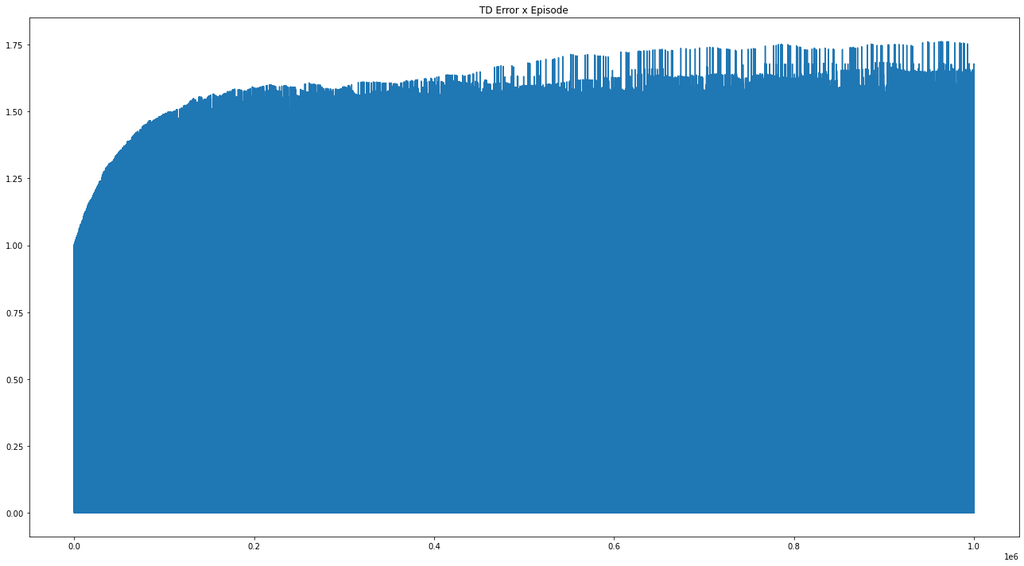

```python
# Mostrem l'evaluació dels td_errors per a cada un dels episodis
import matplotlib.pyplot as plt

plt.rcParams["figure.figsize"] = [18, 10]
plt.rcParams["figure.autolayout"] = True

plt.title("TD Error x Episode")

x_coordinate = [ 1 * i for i in range(len(max_td_errors)) ]
plt.plot(x_coordinate,max_td_errors)
plt.show()
```

**Exercici 4.2** (0,25 punts)

Implementar una funció que imprimeixi per pantalla la política òptima trobada per a cada estat.

S'aconsegueix arribar a la política òptima?

**NOTA:** Per respondre la pregunta es recomana implementar una funció que compari la política obtinguda per al conjunt d'estats de la figura 2 amb la política òptima i indiqueu el nombre d'accions no òptimes (si n'hi ha).

```python
######################## SOLUCIÓ ###########################
# Printem la política
def print_policy_SARSA(Q_sarsa):
    for b_usable_ace in (0, 1):
        for i_player in range(12, 22):
            for i_dealer in range(1, 11):
                arr = np.array(Q_sarsa[i_player, i_dealer, b_usable_ace])
                action = arr.argmax()
                print("Usable Ace: {}, Dealer: {}, Player: {}, Action: {}".format(b_usable_ace == 0, i_dealer, i_player, switch_action[action]))
```

```python
print_policy_SARSA(Q_sarsa)
```

```
Usable Ace: True, Dealer: 1, Player: 12, Action: Hit
Usable Ace: True, Dealer: 2, Player: 12, Action: Stick
Usable Ace: True, Dealer: 3, Player: 12, Action: Hit
Usable Ace: True, Dealer: 4, Player: 12, Action: Stick
Usable Ace: True, Dealer: 5, Player: 12, Action: Stick
Usable Ace: True, Dealer: 6, Player: 12, Action: Stick
Usable Ace: True, Dealer: 7, Player: 12, Action: Hit
Usable Ace: True, Dealer: 8, Player: 12, Action: Hit
Usable Ace: True, Dealer: 9, Player: 12, Action: Hit
Usable Ace: True, Dealer: 10, Player: 12, Action: Hit
Usable Ace: True, Dealer: 1, Player: 13, Action: Hit
Usable Ace: True, Dealer: 2, Player: 13, Action: Stick
Usable Ace: True, Dealer: 3, Player: 13, Action: Stick
Usable Ace: True, Dealer: 4, Player: 13, Action: Stick
Usable Ace: True, Dealer: 5, Player: 13, Action: Stick
Usable Ace: True, Dealer: 6, Player: 13, Action: Stick
Usable Ace: True, Dealer: 7, Player: 13, Action: Hit
Usable Ace: True, Dealer: 8, Player: 13, Action: Hit
Usable Ace: True, Dealer: 9, Player: 13, Action: Hit
Usable Ace: True, Dealer: 10, Player: 13, Action: Hit
Usable Ace: True, Dealer: 1, Player: 14, Action: Hit
Usable Ace: True, Dealer: 2, Player: 14, Action: Stick
Usable Ace: True, Dealer: 3, Player: 14, Action: Stick
Usable Ace: True, Dealer: 4, Player: 14, Action: Stick
Usable Ace: True, Dealer: 5, Player: 14, Action: Stick
Usable Ace: True, Dealer: 6, Player: 14, Action: Stick
Usable Ace: True, Dealer: 7, Player: 14, Action: Hit
Usable Ace: True, Dealer: 8, Player: 14, Action: Hit
Usable Ace: True, Dealer: 9, Player: 14, Action: Hit
Usable Ace: True, Dealer: 10, Player: 14, Action: Hit
Usable Ace: True, Dealer: 1, Player: 15, Action: Hit
Usable Ace: True, Dealer: 2, Player: 15, Action: Stick
Usable Ace: True, Dealer: 3, Player: 15, Action: Stick
Usable Ace: True, Dealer: 4, Player: 15, Action: Stick
Usable Ace: True, Dealer: 5, Player: 15, Action: Stick
Usable Ace: True, Dealer: 6, Player: 15, Action: Stick
Usable Ace: True, Dealer: 7, Player: 15, Action: Hit
Usable Ace: True, Dealer: 8, Player: 15, Action: Hit
Usable Ace: True, Dealer: 9, Player: 15, Action: Hit
Usable Ace: True, Dealer: 10, Player: 15, Action: Hit
```

[output cut: 145 more lines]

```
Usable Ace: False, Dealer: 6, Player: 20, Action: Stick
Usable Ace: False, Dealer: 7, Player: 20, Action: Stick
Usable Ace: False, Dealer: 8, Player: 20, Action: Stick
Usable Ace: False, Dealer: 9, Player: 20, Action: Stick
Usable Ace: False, Dealer: 10, Player: 20, Action: Stick
Usable Ace: False, Dealer: 1, Player: 21, Action: Stick
Usable Ace: False, Dealer: 2, Player: 21, Action: Stick
Usable Ace: False, Dealer: 3, Player: 21, Action: Stick
Usable Ace: False, Dealer: 4, Player: 21, Action: Stick
Usable Ace: False, Dealer: 5, Player: 21, Action: Stick
Usable Ace: False, Dealer: 6, Player: 21, Action: Stick
Usable Ace: False, Dealer: 7, Player: 21, Action: Stick
Usable Ace: False, Dealer: 8, Player: 21, Action: Stick
Usable Ace: False, Dealer: 9, Player: 21, Action: Stick
Usable Ace: False, Dealer: 10, Player: 21, Action: Stick
```

```python
def optimal_policy(player, dealer, usable_ace):
    optimal_policy = {}
    optimal_policy[(True, 1)] = 18
    optimal_policy[(True, 2)] = 17
    optimal_policy[(True, 3)] = 17
    optimal_policy[(True, 4)] = 17
    optimal_policy[(True, 5)] = 17
    optimal_policy[(True, 6)] = 17
    optimal_policy[(True, 7)] = 17
    optimal_policy[(True, 8)] = 17
    optimal_policy[(True, 9)] = 18
    optimal_policy[(True, 10)] = 18
    optimal_policy[(False, 1)] = 16
    optimal_policy[(False, 2)] = 12
    optimal_policy[(False, 3)] = 12
    optimal_policy[(False, 4)] = 11
    optimal_policy[(False, 5)] = 11
    optimal_policy[(False, 6)] = 11
    optimal_policy[(False, 7)] = 16
    optimal_policy[(False, 8)] = 16
    optimal_policy[(False, 9)] = 16
    optimal_policy[(False, 10)] = 16

    max_player = optimal_policy[usable_ace, dealer]
    if player <= max_player:
        action = 1
    else:
        action = 0

    return action


def compara_sarsa(Q_sarsa):
    switch_action = {
        0: "Stick",
        1: "Hit",
    }
    errors = 0
    i = 0
    for b_usable_ace in (0, 1):
        for i_player in range(12, 22):
            for i_dealer in range(1, 11):
                arr = np.array(Q_sarsa[i_player, i_dealer, b_usable_ace])
                action_td_policy = arr.argmax()
                action_optimal_policy = optimal_policy(i_player,i_dealer,b_usable_ace)
                if (action_td_policy != action_optimal_policy):
                    errors = errors + 1
                i = i + 1
    return errors
```

```python
errors = compara_sarsa(Q_sarsa)
print("Número total d'errors = {}".format(errors))
```

```
Número total d'errors = 6
```

**Comentaris:**

L'algoritme Sarsa té una convergencia menys acurada que Montecarlo ja que hem obtingut 6 errors però és cert que hem fet menys interacions. L'aprenentatge segurament és més ràpid ja que Sarsa no s'espera al final de la iteració per actualitzar Q com fa Montecarlo sino que en cada pas de la iteració actualitza.

Si el loop per a generar la política tendís a infinit aconseguiriem la política exacta ja que les dues suposicions per garantir la política óptima és que el nombre d'episodis sigui infinit i que es visiti tots els parells estat-acció. Aquesta darrera suposició es compleix però la primera obviament no és possible.

**Exercici 4.3** (0,25 punts)

Utilitzant l'agent obtingut mitjançant el mètode de MC, simular 100.000 partides i calcular el retorn de l'agent (recompensa total acumulada).

Calculeu el % de victòries, derrotes i empats i comparar-los amb els de l'apartat 2. A què es deuen les possibles diferències?

```python
######################## SOLUCIÓ ###########################
# Retorna el percentatge entre el valor a i b
def percent_of(num_a, num_b):
    return (num_a / num_b) * 100


# Executa una partida amb la política calculada amb montecarlo
def play_game(sarsa_policy):
    obs = env.reset()
    total_reward, done = 0, False

    switch_action = {
        0: "Stick",
        1: "Hit",
    }

    while not done:
        # obtenim l'acció a executar a partir de la política de sarsa_policy
        arr = np.array(sarsa_policy[obs[0], obs[1], obs[2]])
        action_sarsa_policy = arr.argmax()
        # executem l'acció y esperem la resposta de l'entorn
        new_obs, reward, done, info = env.step(action_sarsa_policy)
        # actualizar variables
        obs = new_obs
        total_reward += reward
    return total_reward


# Executem la partida tantes vegades com indica el valor de 'games' amb la política 'sarsa_policy' i l'environtment 'env'.
def play_games_sarsa(env, sarsa_policy, num_games):
    total_reward = 0
    current_game = 0
    total_win = 0
    total_lose = 0
    total_draw = 0

    while current_game < games:
        reward = play_game(sarsa_policy)
        if (reward == 0):
            total_draw += 1
        elif (reward == -1):
            total_lose += 1
        elif (reward == 1):
            total_win += 1
        total_reward += reward
        current_game = current_game + 1

    return total_reward, total_win, total_lose, total_draw
env.close()
```

```python
games = 100000
total_reward, total_win, total_lose, total_draw = play_games_sarsa(env, Q_sarsa, games)

print("{} jocs executats amb una recompensa total de {} ".format(games, total_reward))
print("El nombre de victories totals és de {} amb un percentatge del {}%".format(total_win, percent_of(total_win, games)))
print("El nombre de derrotes és de {} amb un percentatge del {}%".format(total_lose, percent_of(total_lose, games)))
print("El nombre d'empats és de {} amb un percentatge del {}%".format(total_draw, percent_of(total_draw, games)))
```

```
100000 jocs executats amb una recompensa total de -4690
El nombre de victories totals és de 43131 amb un percentatge del 43.131%
El nombre de derrotes és de 47821 amb un percentatge del 47.821000000000005%
El nombre d'empats és de 9048 amb un percentatge del 9.048%
```

**Comentaris:**

Els valors a l'executar les 100000 partides no difereixen gaire amb una diferència d'errors tan petita entre un algoritme i l'altre.

## 5. Comparativa dels algorismes (2 punts)

En aquest apartat farem una comparativa entre els algoritmes.

Compararem el comportament dels algorismes en modificar els valors del factor de descompte, el learning rate (en el cas del mètode SARSA) i el nombre d'episodis.

Per a cada exercici cal mostrar i justificar els resultats.

NOTA: es recomana fer diverses vegades les simulacions en cada exercici, ja que aquestes són aleatòries, i comentar-ne el resultat més freqüent, o una mitjana.

**Exercici 5.1-Influència del nombre d'episodis** (1 punt)

Realitzar un estudi canviant el nombre d'episodis a cadascun dels 2 algorismes:

- Entrenar cada algorisme diverses vegades amb 100.000, 1.000.0000, 5.000.000 i 10.000.000 d'episodis i fer una mitjana dels resultats
- Indicar com influeix el nombre d'episodis en la convergència de cada algorisme, calculant el nombre d'estats en què la política difereix de l'òptima així com la mitjana del retorn obtingut en jugar 100.000 partides després de cada entrenament.

Per a acada nombre d'episodis d'entrenament, es repeteix l'entrenament un nombre de vegades (5, 10 o les que consideris) i després de cada entrenament: compares la política obtinguda amb l'òptima per veure el nombre d'accions errònies sobre el conjunt total d'estats i jugues 100.000 partides amb la política obtinguda i calcules el retorn. Després fas la mitja d'aquets 2 valors respecte el nombre de vegades que has entrenat Aquest procediment s'ha de repetir per al diferent nombre d'episodis d'entrenament per a fer una comparativa (per exemple pots graficar l'evolució dels 2 paràmtres en funció del nombre d'episodis d'entrenament)

```python
iterations = 5
num_episodes = [100000, 1000000, 5000000, 10000000]
games = 100000

avg_errors_mc = []
avg_errors_sarsa = []

avg_reward_mc = []
avg_reward_sarsa = []


for episodes in num_episodes:
    total_errors_mc = 0
    total_errors_sarsa = 0
    total_reward_mc = 0
    total_reward_sarsa = 0
    for i in range(iterations):

        print('\033[1m' + "Inici iteració: {} i {} episodis.".format(i, episodes)+ '\033[0m')
        print("Executem Montecarlo Agorithm amb {} episodis.".format(episodes))
        Q_mc, policy_mc = mc_learning(env, episodes, discount=1)
        errors = compara_mc(Q_mc)
        print("Número total d'errors amb Montecarlo i {} episodis = {}".format(episodes, errors))
        total_errors_mc += errors
        print("--------------------------------------------------------------------------------")


        print("Executem SARSA Agorithm amb {} episodis.".format(episodes))
        Q_sarsa, max_td_errors, end_td_errors = sarsa_learning(env, episodes, learning_rate=0.001, discount=1)
        errors = compara_sarsa(Q_sarsa)
        print("Número total d'errors amb SARSA i {} episodis = {}".format(episodes, errors))
        total_errors_sarsa += errors
        print("--------------------------------------------------------------------------------")

        print("Juguem {} partides amb política generada amb Montecarlo i {} episodis".format(games, episodes))
        total_reward, total_win, total_lose, total_draw = play_games_mc(env, Q_mc, games)
        total_reward_mc += total_reward
        print("Reward total amb Montecarlo, {} episodis i {} games = {}".format(episodes, games, total_reward))
        print("--------------------------------------------------------------------------------")

        print("Juguem {} partides amb política generada amb Sarsa i {} episodis".format(games, episodes))
        total_reward, total_win, total_lose, total_draw = play_games_sarsa(env, Q_sarsa, games)
        total_reward_sarsa += total_reward
        print("Reward total amb Sarsa, {} episodis i {} games = {}".format(episodes, games, total_reward))
        print("--------------------------------------------------------------------------------")

    avg_errors_mc.append(total_errors_mc / iterations)
    avg_errors_sarsa.append(total_errors_sarsa / iterations)
    avg_reward_mc.append(total_reward_mc / iterations)
    avg_reward_sarsa.append(total_reward_sarsa / iterations)
```

```
Inici iteració: 0 i 100000 episodis.
Executem Montecarlo Agorithm amb 100000 episodis.
Episode 100000/100000.Número total d'errors amb Montecarlo i 100000 episodis = 13
--------------------------------------------------------------------------------
Executem SARSA Agorithm amb 100000 episodis.
Episode 99000/100000.Número total d'errors amb SARSA i 100000 episodis = 14
--------------------------------------------------------------------------------
Juguem 100000 partides amb política generada amb Montecarlo i 100000 episodis
Reward total amb Montecarlo, 100000 episodis i 100000 games = -4875
--------------------------------------------------------------------------------
Juguem 100000 partides amb política generada amb Sarsa i 100000 episodis
Reward total amb Sarsa, 100000 episodis i 100000 games = -5993
--------------------------------------------------------------------------------
Inici iteració: 1 i 100000 episodis.
Executem Montecarlo Agorithm amb 100000 episodis.
Episode 100000/100000.Número total d'errors amb Montecarlo i 100000 episodis = 13
--------------------------------------------------------------------------------
Executem SARSA Agorithm amb 100000 episodis.
Episode 99000/100000.Número total d'errors amb SARSA i 100000 episodis = 20
--------------------------------------------------------------------------------
Juguem 100000 partides amb política generada amb Montecarlo i 100000 episodis
Reward total amb Montecarlo, 100000 episodis i 100000 games = -5133
--------------------------------------------------------------------------------
Juguem 100000 partides amb política generada amb Sarsa i 100000 episodis
Reward total amb Sarsa, 100000 episodis i 100000 games = -6285
--------------------------------------------------------------------------------
Inici iteració: 2 i 100000 episodis.
Executem Montecarlo Agorithm amb 100000 episodis.
Episode 100000/100000.Número total d'errors amb Montecarlo i 100000 episodis = 7
--------------------------------------------------------------------------------
Executem SARSA Agorithm amb 100000 episodis.
Episode 99000/100000.Número total d'errors amb SARSA i 100000 episodis = 21
--------------------------------------------------------------------------------
Juguem 100000 partides amb política generada amb Montecarlo i 100000 episodis
Reward total amb Montecarlo, 100000 episodis i 100000 games = -4561
--------------------------------------------------------------------------------
Juguem 100000 partides amb política generada amb Sarsa i 100000 episodis
Reward total amb Sarsa, 100000 episodis i 100000 games = -6310
--------------------------------------------------------------------------------
Inici iteració: 3 i 100000 episodis.
```

[output cut: 205 more lines]

```
Reward total amb Sarsa, 10000000 episodis i 100000 games = -4471
--------------------------------------------------------------------------------
Inici iteració: 4 i 10000000 episodis.
Executem Montecarlo Agorithm amb 10000000 episodis.
Episode 10000000/10000000.Número total d'errors amb Montecarlo i 10000000 episodis = 0
--------------------------------------------------------------------------------
Executem SARSA Agorithm amb 10000000 episodis.
Episode 9999000/10000000.Número total d'errors amb SARSA i 10000000 episodis = 2
--------------------------------------------------------------------------------
Juguem 100000 partides amb política generada amb Montecarlo i 10000000 episodis
Reward total amb Montecarlo, 10000000 episodis i 100000 games = -4921
--------------------------------------------------------------------------------
Juguem 100000 partides amb política generada amb Sarsa i 10000000 episodis
Reward total amb Sarsa, 10000000 episodis i 100000 games = -5147
--------------------------------------------------------------------------------
```

```python
print(avg_errors_mc)
print(avg_errors_sarsa)
print(avg_reward_mc)
print(avg_reward_sarsa)
```

```
[11.0, 4.4, 0.4, 0.2]
[19.6, 8.2, 5.2, 4.0]
[-4870.4, -4718.8, -4663.0, -4960.2]
[-6361.8, -4916.0, -4870.2, -4706.2]
```

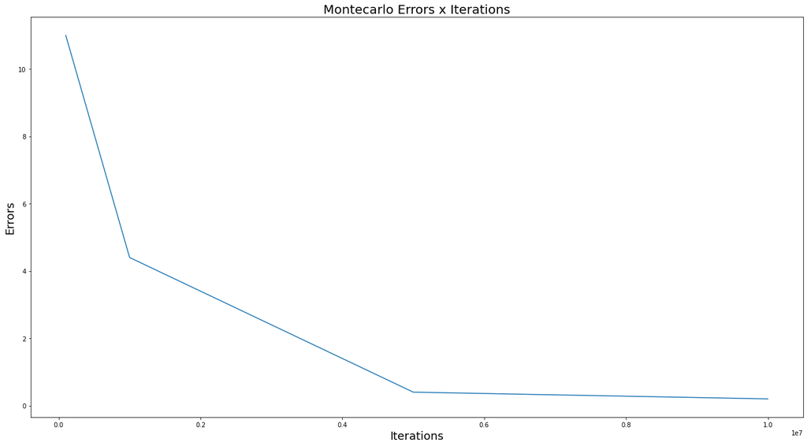

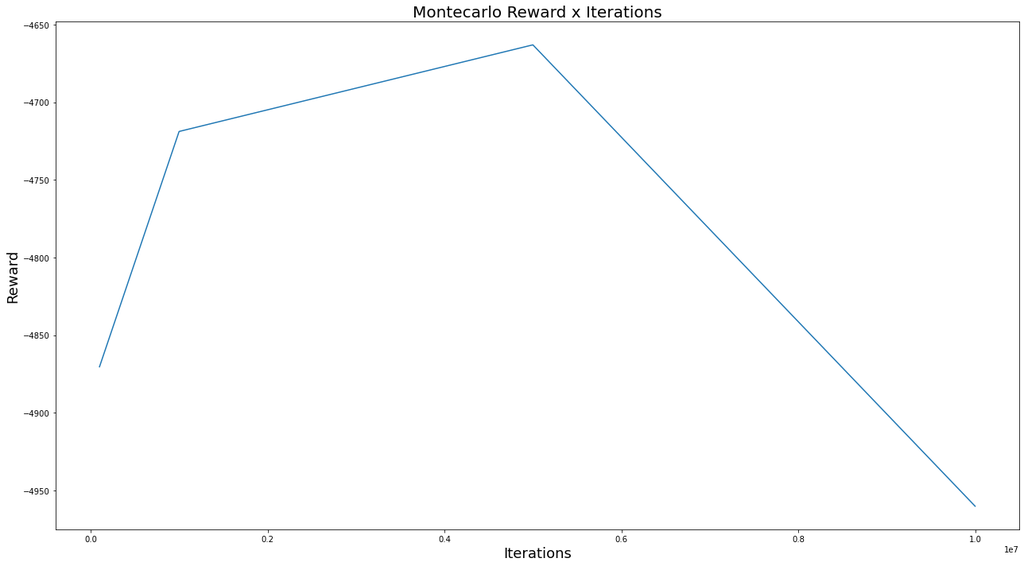

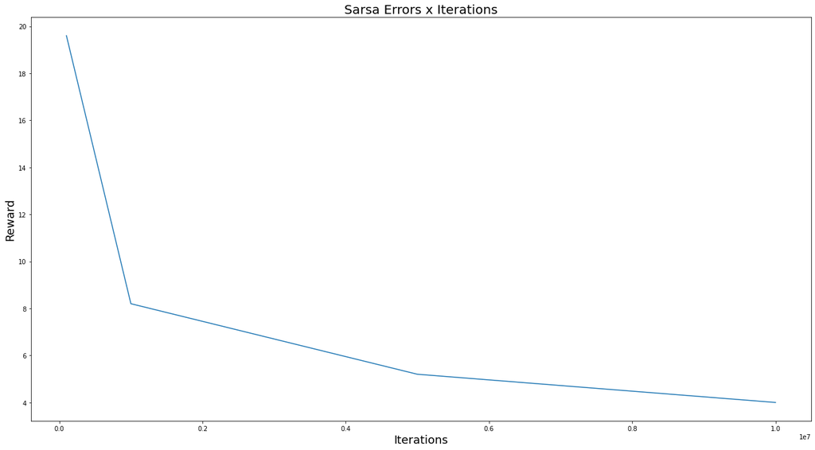

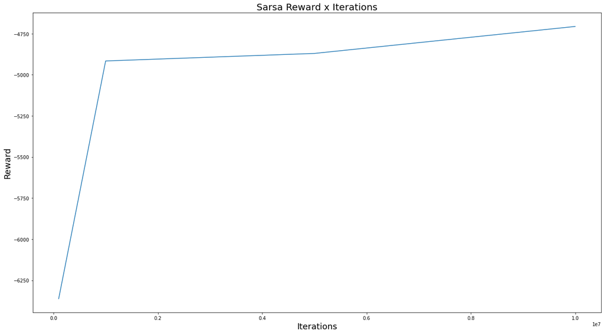

```python
plt.rcParams["figure.figsize"] = [18, 10]
plt.rcParams["figure.autolayout"] = True

plt.title("Montecarlo Errors x Iterations", fontsize=20)
plt.xlabel('Iterations', fontsize=18)
plt.ylabel('Errors', fontsize=18)
plt.plot(num_episodes, avg_errors_mc)
plt.show()

plt.title("Montecarlo Reward x Iterations", fontsize=20)
plt.xlabel('Iterations', fontsize=18)
plt.ylabel('Reward', fontsize=18)
plt.plot(num_episodes, avg_reward_mc)
plt.show()

plt.title("Sarsa Errors x Iterations", fontsize=20)
plt.xlabel('Iterations', fontsize=18)
plt.ylabel('Reward', fontsize=18)
plt.plot(num_episodes, avg_errors_sarsa)
plt.show()

plt.title("Sarsa Reward x Iterations", fontsize=20)
plt.xlabel('Iterations', fontsize=18)
plt.ylabel('Reward', fontsize=18)
plt.plot(num_episodes, avg_reward_sarsa)
plt.show()
```

**Algoritme Sarsa**: l'algoritme Sarsa li costa més arribar a la política óptima. Amb el màxim d'iteracions tenim una mitja de 4 errors en les polítiques calculades. Per tant, sembla que Montecarlo sigui més eficient que no pas Sarsa. De totes formes, com hem comentat previament si augmentéssim el número de execucions i tendís a infinit tindriem polítiques óptimes.

**Exercici 5.2-Influència del factor de descompte** (0,5 puntos)

Executar els 2 algorismes amb *disccount factor*=0.1 i la resta de paràmetres iguals que en els exercicis 3 i 4. Descriure els canvis en la política òptima, comparant el resultat obtingut amb el resultat dels exercicis 3 i 4 (*discount factor* =1).

```python
######################## SOLUCIÓ MC ###########################
discount = 0.01
episodes = 5000000
Q_mc, policy_mc = mc_learning(env, episodes, discount)
errors = compara_mc(Q_mc)
print("Número total d'errors amb Montecarlo, {} episodis i discount {} = {}".format(episodes, discount, errors))
total_reward, total_win, total_lose, total_draw = play_games_mc(env, Q_mc, games)
print("Reward total amb Montecarlo, {} episodis, {} games i discount {} = {}".format(episodes, games, discount, total_reward))
```

```
Número total d'errors amb Montecarlo, 5000000 episodis i discount 0.01 = 11
Reward total amb Montecarlo, 5000000 episodis, 100000 games i discount 0.01 = -5361
```

```python
######################## SOLUCIÓ SARSA ###########################
discount = 0.01
episodes = 1000000
Q_sarsa, max_td_errors, end_td_errors = sarsa_learning(env, episodes, learning_rate=0.001, discount=0.01)
errors = compara_sarsa(Q_sarsa)
print("Número total d'errors amb Sarsa, {} episodis i discount {} = {}".format(episodes, discount, errors))
total_reward, total_win, total_lose, total_draw = play_games_sarsa(env, Q_sarsa, games)
print("Reward total amb Sarsa, {} episodis, {} games i discount {} = {}".format(episodes, games, discount, total_reward))
```

```
Episode 999000/1000000.Número total d'errors amb Sarsa, 1000000 episodis i discount 0.01 = 10
Reward total amb Sarsa, 1000000 episodis, 100000 games i discount 0.01 = -5430
```

**CONCLUSIONS:**

Disminuir el factor de descompte implica que el valor de les recompenses futures tenen menys pes. Tenim un retorn pesimista de les recompenses futures o un agent miop ja que estem diluïnt al multiplicar les recompenses futures per un número clarament inferior a 1, molt proper a 0.

Tant en Montecarlo com en Sarsa aquesta decissió ens penalitza ja que tenim més errors. Això ens indica que el valor de les recompenses futures estimades és important en ambdós algoritmes.

**Exercici 5.3-Influència del learning rate** (0,5 puntos)

Executar l'algoritme de *SARSA* amb els següents valors de *learning rate*: 0.001, 0.01, 0.1 i 0.9. Analitzar les diferències amb els resultats obtinguts a la pregunta 4 en termes de nombre d'errors respecte a la política òptima i de recompensa acumulada cada 100.000 episodis jugats.

```python
######################## SOLUCIÓ ###########################
iterations = 5
learning_rates = [0.001, 0.01, 0.1, 0.9]
games = 100000
episodes = 1000000

errors_sarsa = []
reward_sarsa = []

for learning_rate in learning_rates:

    total_errors = 0
    total_reward_sarsa = 0

    for i in range(iterations):
        Q_sarsa, max_td_errors, end_td_errors = sarsa_learning(env, episodes, learning_rate, discount=1)
        errors = compara_sarsa(Q_sarsa)
        print("Número total d'errors amb SARSA, {} episodis i learning rate {} = {}".format(episodes, learning_rate, errors))

        total_reward, total_win, total_lose, total_draw = play_games_sarsa(env, Q_sarsa, games)
        print("Reward total amb Sarsa, {} episodis, {} games i learning rate {} = {}".format(episodes, games, learning_rate, total_reward))
        print("--------------------------------------------------------------------------------")

        total_errors += errors
        total_reward_sarsa += total_reward

    errors_sarsa.append(total_errors / iterations)
    reward_sarsa.append(total_reward_sarsa / iterations)
```

```
Episode 999000/1000000.Número total d'errors amb SARSA, 1000000 episodis i learning rate 0.001 = 5
Reward total amb Sarsa, 1000000 episodis, 100000 games i learning rate 0.001 = -5114
--------------------------------------------------------------------------------
Episode 999000/1000000.Número total d'errors amb SARSA, 1000000 episodis i learning rate 0.001 = 8
Reward total amb Sarsa, 1000000 episodis, 100000 games i learning rate 0.001 = -4923
--------------------------------------------------------------------------------
Episode 999000/1000000.Número total d'errors amb SARSA, 1000000 episodis i learning rate 0.001 = 10
Reward total amb Sarsa, 1000000 episodis, 100000 games i learning rate 0.001 = -4646
--------------------------------------------------------------------------------
Episode 999000/1000000.Número total d'errors amb SARSA, 1000000 episodis i learning rate 0.001 = 11
Reward total amb Sarsa, 1000000 episodis, 100000 games i learning rate 0.001 = -4714
--------------------------------------------------------------------------------
Episode 999000/1000000.Número total d'errors amb SARSA, 1000000 episodis i learning rate 0.001 = 5
Reward total amb Sarsa, 1000000 episodis, 100000 games i learning rate 0.001 = -5235
--------------------------------------------------------------------------------
Episode 999000/1000000.Número total d'errors amb SARSA, 1000000 episodis i learning rate 0.01 = 5
Reward total amb Sarsa, 1000000 episodis, 100000 games i learning rate 0.01 = -4788
--------------------------------------------------------------------------------
Episode 999000/1000000.Número total d'errors amb SARSA, 1000000 episodis i learning rate 0.01 = 7
Reward total amb Sarsa, 1000000 episodis, 100000 games i learning rate 0.01 = -4732
--------------------------------------------------------------------------------
Episode 999000/1000000.Número total d'errors amb SARSA, 1000000 episodis i learning rate 0.01 = 7
Reward total amb Sarsa, 1000000 episodis, 100000 games i learning rate 0.01 = -4951
--------------------------------------------------------------------------------
Episode 999000/1000000.Número total d'errors amb SARSA, 1000000 episodis i learning rate 0.01 = 10
Reward total amb Sarsa, 1000000 episodis, 100000 games i learning rate 0.01 = -5154
--------------------------------------------------------------------------------
Episode 999000/1000000.Número total d'errors amb SARSA, 1000000 episodis i learning rate 0.01 = 8
Reward total amb Sarsa, 1000000 episodis, 100000 games i learning rate 0.01 = -5348
--------------------------------------------------------------------------------
Episode 999000/1000000.Número total d'errors amb SARSA, 1000000 episodis i learning rate 0.1 = 29
Reward total amb Sarsa, 1000000 episodis, 100000 games i learning rate 0.1 = -7498
--------------------------------------------------------------------------------
Episode 999000/1000000.Número total d'errors amb SARSA, 1000000 episodis i learning rate 0.1 = 20
Reward total amb Sarsa, 1000000 episodis, 100000 games i learning rate 0.1 = -6284
--------------------------------------------------------------------------------
Episode 999000/1000000.Número total d'errors amb SARSA, 1000000 episodis i learning rate 0.1 = 23
Reward total amb Sarsa, 1000000 episodis, 100000 games i learning rate 0.1 = -6598
--------------------------------------------------------------------------------
Episode 999000/1000000.Número total d'errors amb SARSA, 1000000 episodis i learning rate 0.1 = 20
Reward total amb Sarsa, 1000000 episodis, 100000 games i learning rate 0.1 = -5288
--------------------------------------------------------------------------------
Episode 999000/1000000.Número total d'errors amb SARSA, 1000000 episodis i learning rate 0.1 = 23
Reward total amb Sarsa, 1000000 episodis, 100000 games i learning rate 0.1 = -6104
--------------------------------------------------------------------------------
Episode 999000/1000000.Número total d'errors amb SARSA, 1000000 episodis i learning rate 0.9 = 38
Reward total amb Sarsa, 1000000 episodis, 100000 games i learning rate 0.9 = -7969
--------------------------------------------------------------------------------
Episode 999000/1000000.Número total d'errors amb SARSA, 1000000 episodis i learning rate 0.9 = 46
Reward total amb Sarsa, 1000000 episodis, 100000 games i learning rate 0.9 = -9715
--------------------------------------------------------------------------------
Episode 999000/1000000.Número total d'errors amb SARSA, 1000000 episodis i learning rate 0.9 = 48
Reward total amb Sarsa, 1000000 episodis, 100000 games i learning rate 0.9 = -12554
--------------------------------------------------------------------------------
Episode 999000/1000000.Número total d'errors amb SARSA, 1000000 episodis i learning rate 0.9 = 40
Reward total amb Sarsa, 1000000 episodis, 100000 games i learning rate 0.9 = -13299
--------------------------------------------------------------------------------
Episode 999000/1000000.Número total d'errors amb SARSA, 1000000 episodis i learning rate 0.9 = 46
Reward total amb Sarsa, 1000000 episodis, 100000 games i learning rate 0.9 = -9337
--------------------------------------------------------------------------------
```

**CONCLUSIONS:**

```python
print(errors_sarsa)
print(reward_sarsa)
```

```
[7.8, 7.4, 23.0, 43.6]
[-4926.4, -4994.6, -6354.4, -10574.8]
```

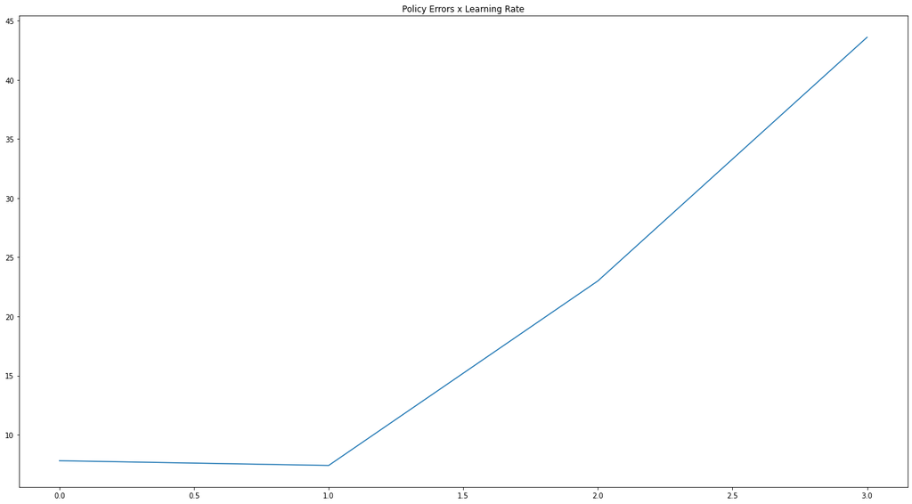

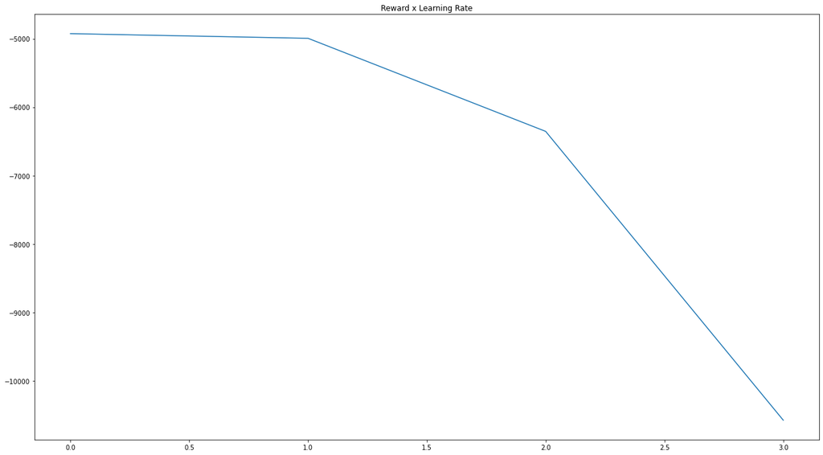

```python
plt.title("Policy Errors x Learning Rate")
plt.plot(errors_sarsa)
plt.show()

plt.title("Reward x Learning Rate")
plt.plot(reward_sarsa)
plt.show()
```

El valor de learning rate en l'algoritme Sarsa indica com de ràpid apren l'algoritme en cada una de les actualitzacions de Q. Concretament en Sarsa afecta al valor de les recompenses futures (o td error) i de retruc a la funció de valor. Com més gran sigui el learning rate més ràpid es concluoran les decissions per a cada un dels estats però amb més errors respecte a la óptima.